# One Sample Means - Week 1, Lecture 2

Author

Hector Gavilanes

```r
library(tidyverse)
library(gsheet)
library(formattable)
```

**Recall the data from the abstract of research study (beginning on page 62). We examined data from 22 elementary schools located in a Florida school district in 1999. Reading and math scores from a standardized test, percent minority of the particular grade level in that school, percent in poverty of the particular grade level in that school, and total number of students in that grade at that school are included.**

```r
# clear environment
rm(list = ls())
# extract data
data <- as_tibble(gsheet2tbl("https://docs.google.com/spreadsheets/d/1cVGLLdILMI34xjnzHfJNHua6fJROJwCzUBFgV22OLT4/edit#gid=0"))
# transform data
clean_data <- data %>%
  # delete empty rows
  drop_na() %>%
  # rename columns
  rename(Poverty = `%Poverty`) %>%
  rename(Minority = `%Minority`)
# ***FUNCTIONS***
# f01 // change default table format
change_table <- function(table_name){
  formattable(
  table_name, align =c("c","c", "c"),
  list(area() ~ color_text("black", "#555888"))
  )
}
# f02 // get course by grade level
get_course_grade_level <- function(level, course){
  clean_data %>%
    filter(Grade == level) %>%
    select(!! sym(course))
  }
# f03 // get course confidence intervals for each grade
get_mean_ci_course_byGrade <- function(course){
  clean_data %>%
    group_by(Grade) %>%
    summarise(
      mean_course = mean(!! sym(course)),
      ci_low = t.test(!! sym(course), conf.level = 0.95)$conf.int[1],
      ci_up = t.test(!! sym(course), conf.level = 0.95)$conf.int[2]
    )
}
# f04 // graph course confidence intervals for each grade
plot_ci_course <- function(mean_ci){
  mean_ci%>%
    ggplot(aes(x=Grade, y = mean_course, fill = factor(Grade)))+
    geom_bar(stat = "identity")+
    scale_fill_manual(values=c("#c2d4dd", "#b1cbbb", "#e4d1d1"))+
    geom_errorbar(aes(ymin = ci_low, ymax = ci_up), size = 1.5, color = "#034f84", width = 0.4)+
    geom_text(aes(y = ci_low, label = round(ci_low,1)), size = 4, vjust = 2, color = "black")+
    geom_text(aes(y = ci_up, label = round(ci_up,1)), size = 4, vjust = -1, color = "black")+
    labs(title = "Chart with 95% Confidence Intervals")+
    labs(x="Grades", y="Average Reading Scores")+
    ylim(0, 280)+
    lims(colour = c("3", "4", "5"))+
    theme_bw()+
    theme(legend.position="none")
}
```

#### 1. From last class, what are the average math and reading scores for each grade?

```r
math_read_table <- clean_data %>%
  select(Grade, Math, Reading) %>%
  group_by(Grade) %>%
  summarise(Average_Math = mean(Math), Average_Reading = mean(Reading))
# f01: change math and reading table
change_table(math_read_table)
```

| Grade | Average_Math | Average_Reading |
| --- | --- | --- |
| 3 | 171.8727 | 171.1045 |
| 4 | 189.8818 | 185.9591 |
| 5 | 206.1632 | 205.3632 |

#### 2. Construct the 95% confidence interval for the mean math score for 3rd grade students.

```r
# f02: get math confidence interval by 3rd grade
t.test(get_course_grade_level(3, "Math"))
```

```
    One Sample t-test

data:  get_course_grade_level(3, "Math")
t = 87.991, df = 21, p-value < 2.2e-16
alternative hypothesis: true mean is not equal to 0
95 percent confidence interval:
 167.8106 175.9348
sample estimates:
mean of x
 171.8727
```

## Conclusion

The 95% CI for $\mu$ are (167.8106 points, 175.9348 points)

#### 4. Use the appropriate hypothesis test to determine if the average math score for 3rd grade students is above 165 points. Test at the $\alpha$=0.05 level.

```r
# f02: get math confidence interval by 3rd grade, mu > 165
t.test(get_course_grade_level(3, "Math"), mu = 165, alternative = "greater")
```

```
    One Sample t-test

data:  get_course_grade_level(3, "Math")
t = 3.5185, df = 21, p-value = 0.001021
alternative hypothesis: true mean is greater than 165
95 percent confidence interval:
 168.5116      Inf
sample estimates:
mean of x
 171.8727
```

### Hypotheses

H0: $\mu \le 165$  
H1: $\mu > 165$

### Test

t0 = 3.518

### p-Value

p = 0.001

## Conclusion

Reject H0 at the $\alpha$ = 0.05 level. There is sufficient evidence to suggest that the average math score for 3rd grade students is above 165 points.

#### 5. (Challenge!) Use `ggplot()` to graph the confidence intervals for the average reading scores for each grade.

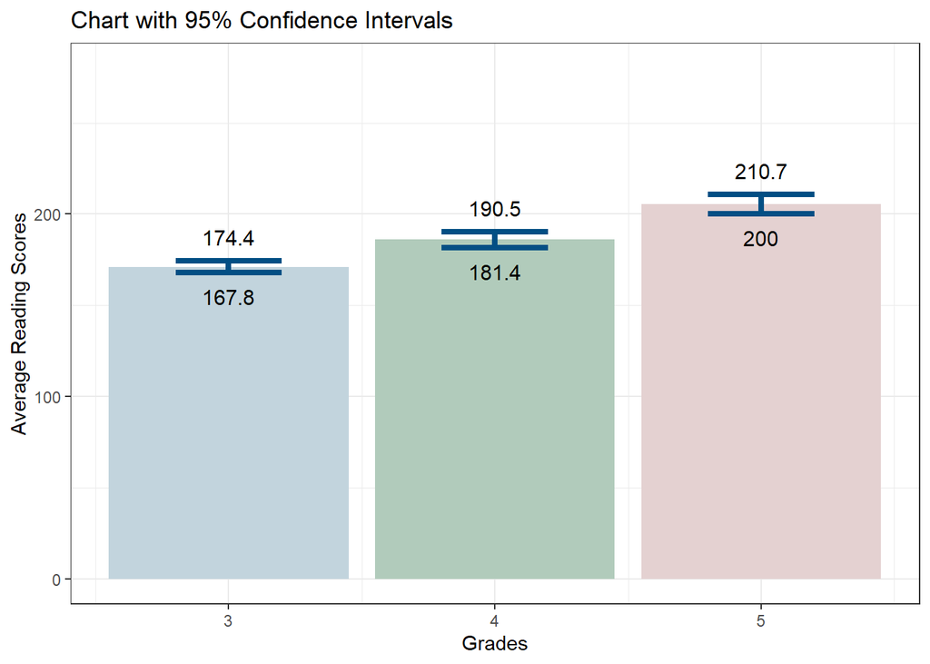

```r
# f04: graph confidence intervals for average READING scores for each grade
plot_ci_course(get_mean_ci_course_byGrade("Reading"))
```